# Replicating UN Voting Ideal Points in Julia

Author

Valeria Farinola

# Overview

This project replicates the Bayesian ideal point estimation procedure from Bailey, Strezhnev, and Voeten (2017), *Estimating Dynamic State Preferences from United Nations Voting Data*.

The goal is to reproduce the estimated United Nations voting ideal points using Julia, compute dyadic ideological distances, and replicate the figure showing the ideal points of the five permanent members of the UN Security Council.

# Original paper and replication package

The original replication package is available at:

https://github.com/evoeten/United-Nations-General-Assembly-Votes-and-Ideal-Points

# Replication goals

The project has three main goals:

1. Replicate the MCMC ideal point estimator implemented in `UN_Ideal_Rcpp.R`.
2. Reproduce country-session ideal point estimates.
3. Compute dyadic ideological distances and replicate the P5 (five permanent members of the UN Security Council) ideal points figure.

# Model summary

The estimator is a Bayesian ideal point model for United Nations voting data.

Each country-session receives a latent ideal point, denoted as theta. Votes are modeled through a latent continuous variable and threshold parameters. The sampler updates theta, gamma thresholds, latent Z variables, and beta discrimination parameters.

# Julia implementation

The Julia implementation includes:

- theta update;
- dynamic lagged prior;
- gamma threshold Metropolis-Hastings update;
- latent Z update;
- beta update;
- MCMC loop with burn-in and thinning;
- posterior storage;
- ideal point export.

# Main replication output

The full All-votes MCMC run used:

- K = 20000
- Burn = 4000
- Thin = 50

The final Julia ideal point estimates are stored in:

```
output/ThetaEst_full_all.csv
```

# Replicated P5 figures

## All votes dataset

### Original replication output

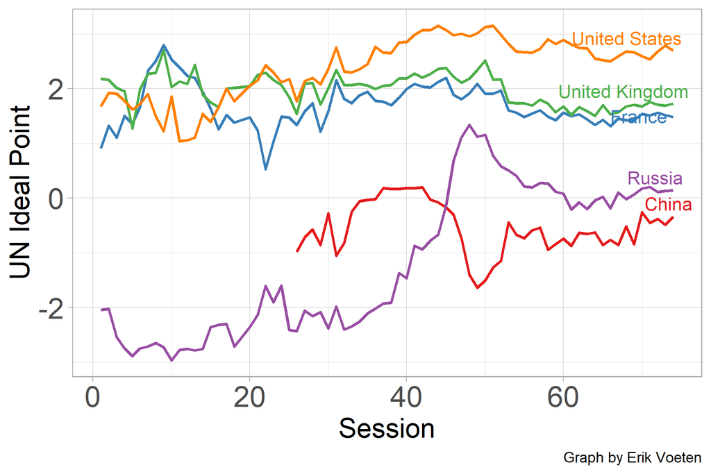

### Julia replication

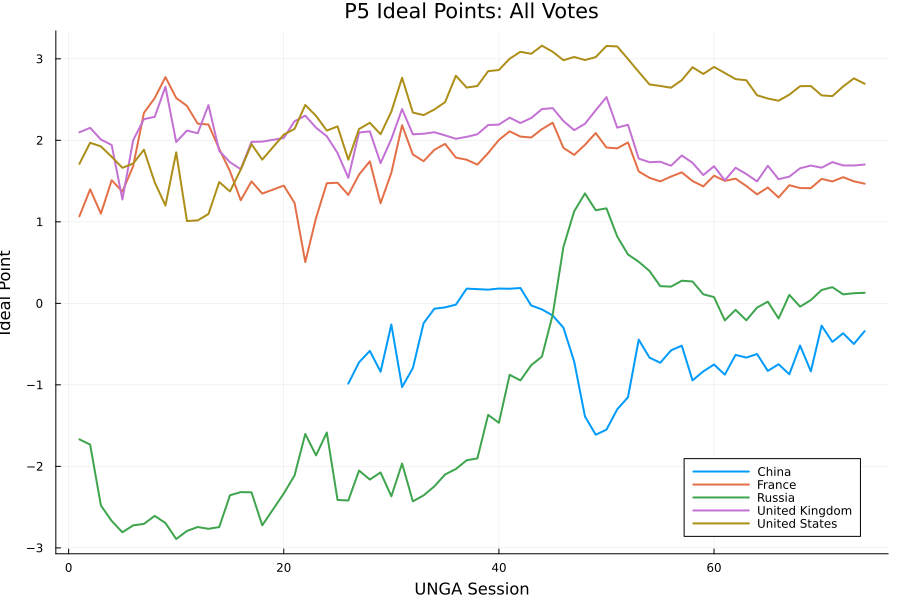

The Julia replication reproduces the main substantive dynamics of the original replication output, including the relative positioning of the United States, USSR/Russia, China, the United Kingdom, and France across UNGA sessions.

## Important votes dataset

### Original replication output

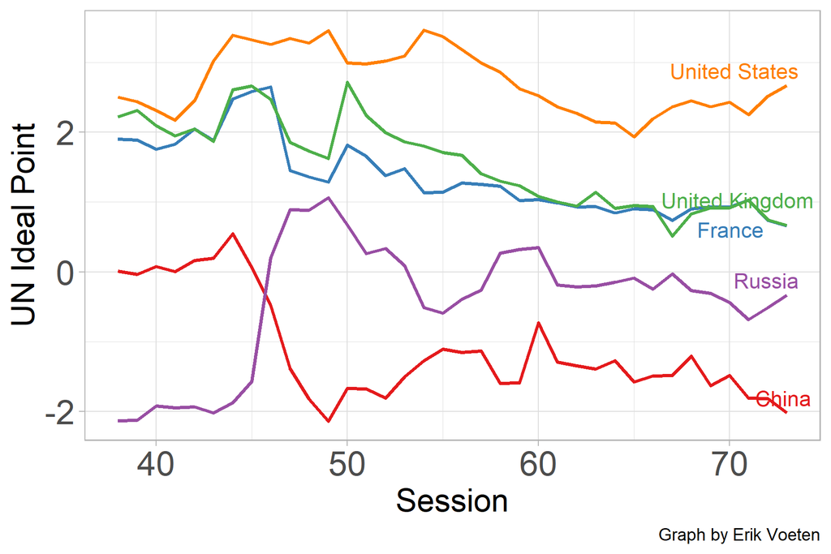

### Julia replication

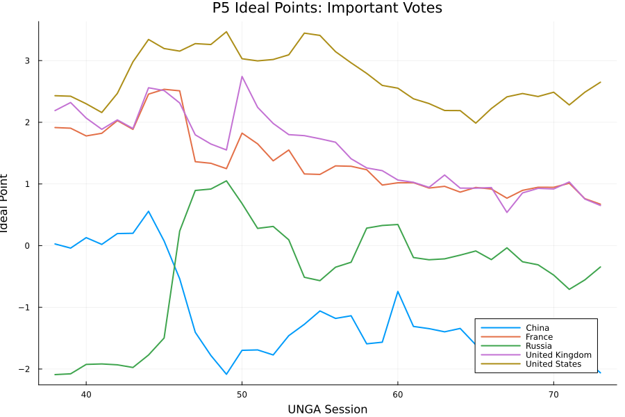

The Julia replication based on the Important-votes subset reproduces the broad structure of the original replication output while reflecting differences due to MCMC sampling variation and implementation details.

# Dyadic ideological distances

Dyadic distances are computed as a post-estimation transformation:

```
distance(i,j) = |theta_i - theta_j|
```

The dyadic distance output is stored in:

```
output/dyadic_distances_full_all.csv
```

# Package tests

The package includes a small test suite covering:

- R-style repetition helper;
- dyadic distance formula.

The tests can be run with:

```julia
using Pkg
Pkg.test()
```

# Conclusion

The Julia implementation successfully reproduces the main computational steps of the original R/Rcpp estimator and generates ideal point estimates for the All-votes dataset. The replicated P5 figure reproduces the main substantive dynamics of the original paper.